# Análisis - Compra-venta de coches usados en UK

Marta Gómez / Juan Fco Nieto

12/17/2021

##### 0.0.0.0.1 Cargar librerías

# 1 Descripción del dataset

## 1.1 Objetivos y descripción del dataset original

El presente proyecto tiene como objetivo final el análisis del mercado de segunda mano de coches de Reino Unido que ayude en la toma de decisiones tanto de un comprador como de un vendedor.

Para poder llevar a cabo dicho objetivo se procede a la integración, limpieza, validación y análisis de un conjunto de datasets de coches usados en Reino Unido creados en Julio 2020 por el usuario ‘Aditya’ (https://www.kaggle.com/adityadesai13 ) a través de web scraping de portales de compraventa británicos. El objetivo inicial del usuario era la creación de un modelo de regresión lineal de coches usados para hacer predicciones sobre la variable target “price”, interpretándose como un análisis del precio de mercado.

Citando al usuario:

*“I collected the data to make a tool to predict how much my friend should sell his old car for compared to other stuff on the market, and then just extended the data set. Then made a more general car value regression model.”*

El resultado del web scraping son 13 ficheros individuales tipo csv, entre los que seleccionamos un total de 9 ficheros, identificados por el nombre del fabricante, con las características de distintos modelos tales como el ano, tipo de combustible, tipo de motor, kilometraje, precio actual, etc… Dichos ficheros se encuentran en el siguiente enlace: https://www.kaggle.com/adityadesai13/used-car-dataset-ford-and-mercedes. El resto de ficheros (“cclass.csv”, “focus.csv”, “unclean cclass.csv” y “unclean focus.csv”) no se tienen en cuenta para el presente análisis.

Para facilitar el estudio procedemos a la integración de los nueve ficheros de interés en un único fichero tipo csv al que llamaremos aprox100KUsedCars.csv. En dicho archivo incluiremos los campos de cada fichero más el campo “manufacturer” con el nombre del fabricante que extraeremos del nombre de cada fichero individual.

# 2 Integración y selección de los datos de interés a analizar

Para la integración de los ficheros hemos utilizado el script Ruby (ruby integration.rb) localizado en la carpeta “integration” en el enlace GitHub cuya ejecución crea en nuestra raíz del proyecto el fichero aprox100KUsedCars.csv. De este modo nos encontramos con un dataset con un total de 99187 filas y 10 columnas que representan 99187 ofertas en portales de compraventa de coches usados en Reino Unido. En la siguiente tabla se muestra un ejemplo del tipo de datos.

```r
# Carga de los datos
used_cars <- read.csv("aprox100KUsedCars.csv", stringsAsFactors = TRUE)

sample_n(used_cars,10)  %>% knitr::kable()
```

| manufacturer | model | year | price | transmission | mileage | fuelType | tax | mpg | engineSize |
| --- | --- | --- | --- | --- | --- | --- | --- | --- | --- |
| vw | Golf | 2018 | 11975 | Manual | 38115 | Petrol | 145 | 55.4 | 1.4 |
| merc | E Class | 2018 | 28306 | Automatic | 10656 | Diesel | 145 | 70.6 | 2.0 |
| vw | Golf | 2015 | 9750 | Manual | 56282 | Diesel | 0 | 68.9 | 1.6 |
| ford | Fiesta | 2020 | 19990 | Manual | 2629 | Petrol | 145 | 55.4 | 1.0 |
| vw | Tiguan | 2017 | 25000 | Automatic | 13947 | Diesel | 145 | 57.6 | 2.0 |
| bmw | 2 Series | 2019 | 19776 | Manual | 110 | Petrol | 145 | 42.8 | 1.5 |
| audi | Q3 | 2019 | 24500 | Manual | 10881 | Petrol | 145 | 40.9 | 1.5 |
| vauxhall | Astra | 2016 | 9990 | Manual | 14419 | Petrol | 125 | 51.4 | 1.4 |
| merc | E Class | 2018 | 31480 | Semi-Auto | 6310 | Diesel | 145 | 57.7 | 2.0 |
| audi | A3 | 2013 | 13930 | Semi-Auto | 30973 | Petrol | 125 | 50.4 | 1.8 |

**Tabla 1. Ejemplo del tipo de datos almacenada en el dataset.**

## 2.1 Descripción de las variables

A continuación mostramos un resumen del tipo de variables presentes en el dataset que constituyen los datos de interés a analizar en el que podemos observar la presencia de dos tipos principales de variables: categóricas (factor) y numéricas (integer o numeric).

```r
# Tabla resumen del tipo de variables que conforman el dataset
tb_var <- sapply(used_cars, class)
knitr::kable(data.frame(variables = names(tb_var), clase = as.vector(tb_var)))
```

| variables | clase |
| --- | --- |
| manufacturer | factor |
| model | factor |
| year | integer |
| price | integer |
| transmission | factor |
| mileage | integer |
| fuelType | factor |
| tax | integer |
| mpg | numeric |
| engineSize | numeric |

**Tabla 2. Tipo de variables**

### 2.1.1 Variables categóricas (factor)

- manufacturer: Fabricante del automóvil. Variable categórica nominal con 9 categorías (Niveles) diferentes.
- model: Modelo del automóvil. Variable categórica nominal con 195 categorías diferentes.
- transmission: Tipo de transmisión. Variable categórica nominal con 4 categorías: manual, automática, semiautomática y otras.
- fuelType: Tipo de combustible. Variable categórica nominal con 5 categorias: diesel, eléctrico, híbrido, gasolina y otros.

```r
sk <- skim(used_cars)
sk %>% yank('factor') %>% select(c(skim_variable, n_unique)) %>% rename(Variable=skim_variable, Niveles=n_unique)  %>% knitr::kable()
```

| Variable | Niveles |
| --- | --- |
| manufacturer | 9 |
| model | 195 |
| transmission | 4 |
| fuelType | 5 |

**Tabla 3. Resumen de las variables categóricas y sus posibles valores**

### 2.1.2 Variables numéricas

- year: Año de matriculación del coche. Variable numérica discreta.
- price: Precio en Libras que se colocó en el portal de compraventa a fecha Julio 2020. Variable numérica continua.
- mileage: kilomwetraje. Millas que el coche ha recorrido desde su puesta en funcionamiento. (En España utilizamos Kilometraje, porque medimos esta distancia en kilómetros). Variable numérica continua.
- tax: Impuesto de circulación (en Libras). Dependiendo de los años del vehículo, emisión de gases (sobre todo) y otros factores este impuesto varía. Variable numérica continua
- mpg: Consumo de combutible del vehículo en millas por galon. Variable numérica continua
- engineSize: Tamaño del motor en litros. Variable numérica continua.

```r
sk %>% yank('numeric') %>% select(c(skim_variable, mean, sd, p25, p50, p75)) %>% rename(Variable=skim_variable, Media=mean, "Desviación Típica"=sd, "Q1"=p25, "Q2/Mediana"=p50, "Q3"=p75)  %>% knitr::kable(digits=3, scientific = FALSE)
```

| Variable | Media | Desviación Típica | Q1 | Q2/Mediana | Q3 |
| --- | --- | --- | --- | --- | --- |
| year | 2017.088 | 2.124 | 2016.0 | 2017.0 | 2019.0 |
| price | 16805.348 | 9866.773 | 9999.0 | 14495.0 | 20870.0 |
| mileage | 23058.914 | 21148.524 | 7425.0 | 17460.0 | 32339.0 |
| tax | 120.300 | 63.151 | 125.0 | 145.0 | 145.0 |
| mpg | 55.167 | 16.139 | 47.1 | 54.3 | 62.8 |
| engineSize | 1.663 | 0.558 | 1.2 | 1.6 | 2.0 |

**Tabla 4. Análisis descriptivo de las variables numéricas**

# 3 Limpieza de los datos

## 3.1 Análisis de valores nulos o vacíos

Se comprueba la no existencia de ceros o elementos vacíos en el dataset mediante la ejecución de la función is_blank creada para tal propósito.

```r
# Se crea la función is_blank que devuelve la presencia (TRUE) o no (FALSE) de valores vacíos ("" o nulos(NA)) en cada una de las variables del dataset

is_blank <-  function(x){
  return (any(x=="") || anyNA(x))
}
used_cars %>% summarise_all(.funs=c('is_blank'), )
```

```
##   manufacturer model  year price transmission mileage fuelType   tax   mpg
## 1        FALSE FALSE FALSE FALSE        FALSE   FALSE    FALSE FALSE FALSE
##   engineSize
## 1      FALSE
```

## 3.2 Análisis de valores atípicos

La representación gráfica en forma de diagrama de barras (boxplot) identifica la presencia de valores extremos superiores en todas las variables numéricas y sólo en algunas se observan también valores extremos inferiores.

[output not shown]

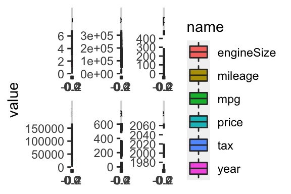

```r
# Boxplot para cada una de las variables númericas (vars)
vars <- c("year", "price", "mileage", "tax", "mpg", "engineSize")

used_cars %>% select(vars) %>% pivot_longer(cols=vars, values_drop_na = TRUE) %>% ggplot(.) + facet_wrap(~name, scales = "free") + geom_boxplot(aes(y=value, fill=name))
```

** Figura 1. Gráfico mostrando los valores extremos de las variables numéricas**

### 3.2.1 Identificación y tratamiento de outliers

Un análisis más profundo nos permite identificar aquellos valores extremos y valorar su tratamiento en función de la información almacenada en dicha varíable.

Para ello creamos la función get_outlier que toma como referencia el método de la diferencia intercuartil (IQR) (ver https://www.r-bloggers.com/2020/01/how-to-remove-outliers-in-r/)

```r
# Creación de la función get_outliers para la identificación de los valores extremos de cada una de las variables numéricas del dataset teniendo en cuenta el método del rango intercuartil (IQR)
get_outliers <- function(x){
  q1 = quantile(x, c(0.25))
  q3 = quantile(x, c(0.75))
  iqr = q3-q1
  result = sapply(x, function(y){
    if(y < q1 - 1.5*iqr){
      y
    }else if(y > q3+1.5*iqr){
      y
    }else{
      NA
    }
  }
  )
  return(list(result, q1 - 1.5*iqr, q3+1.5*iqr))
}
```

La ejecución de la función get_outliers nos permite identificar los valores extremos para cada una de las variables de interés, cuyo resultado mostramos en forma de tabla junto con el rango inferior, rango superior y el número total de outliers identificados y tres ejemplos para cada una de las variables.

```r
# Ejecución de la función get_outliers y su resultado en forma de tabla
final <- list()
outliers_analysis <- used_cars %>% select(vars) %>% sapply(., get_outliers)
for(i in vars){
  ej <- na.omit(outliers_analysis[,i][[1]])

  final <- cbind(final, c(paste(sample(ej, 3), sep=" ", collapse=" / "),  outliers_analysis[,i][[2]], outliers_analysis[,i][[3]], length(ej) ))
}
colnames(final) = vars
rownames(final) = c("Ejemplos", "Inferior", "Superior", "Número total")
data.frame(final) %>% knitr::kable()
```

|  | year | price | mileage | tax | mpg | engineSize |
| --- | --- | --- | --- | --- | --- | --- |
| Ejemplos | 2011 / 2009 / 2008 | 55990 / 37490 / 46995 | 77500 / 80000 / 70122 | 20 / 20 / 0 | 156.9 / 0.3 / 21.4 | 4 / 4 / 5.5 |
| Inferior | 2011.5 | -6307.5 | -29946 | 95 | 23.55 | -2.22044604925031e-16 |
| Superior | 2023.5 | 37176.5 | 69710 | 175 | 86.35 | 3.2 |
| Número total | 1737 | 3669 | 3902 | 28815 | 939 | 650 |

**Tabla 5. Valores extremos.**

A continuación detallamos el tratamiento de los valores extremos en función del tipo de variable así como las inconsistencias encontradas tras su análisis.

- Year: El año de matriculación no puede ser superior al año de la recogida de los datos (Julio 2020), por lo que eliminaremos del dataset aquellos coches con fecha de matriculación superior al 2020. Por otra parte, aunque el análisis muestra como valores extremos los coches matriculados antes del 2011, consideramos estos coches minoritarios pero válidos y los mantendremos en el dataset.

```r
# Eliminamos los coches matriculados más tarde del 2020
original_used_cars <- used_cars
used_cars <- used_cars %>% filter(year <= 2020)
```

- Price: El análisis de valores extremos pone en evidencia una gran dispersión entre los distintos precios de los coches, con un rango inferior negativo. Dado que un valor negativo en el precio sería un claro error lo comprobamos y observamos que no existen. Sin embargo vemos que hay un porcentaje minoritario de coches, probablemente de alta gama, con un precio muy elevado sobre la media que en principio son reconocidos como valores extremos. Sin embargo, los consideramos válidos.

```r
# Comprobamos que no hay coches con precio negativo
used_cars_neg_price <- used_cars %>% filter(price <= 0)
nrow(used_cars_neg_price)
```

```
## [1] 0
```

- Mileage: de igual manera no podemos aceptar kilometraje negativo, por lo que lo comprobamos y observamos que no existen. Al igual que en la variable price, hay una gran dispersión en esta variable. Dado que se trata de compra-venta de coches de segunda mano asumimos una gran variedad de ofertas de coches y los consideramos válidos.

```r
used_cars_neg_mil <- used_cars %>% filter(mileage <= 0)
nrow(used_cars_neg_mil)
```

```
## [1] 0
```

- Tax: El diagrama de barras muestra una clara estratifiación en los impuestos en el que observamos tres tramos. Consideramos válidos los valores extremos mostrados en el análisis. Sin embargo eliminamos los valores iguales a 0.

```r
used_cars <- used_cars %>% filter(tax > 0)
```

- Mpg: debemos tener en cuenta que nuestro dataset contiene tanto coches híbridos como eléctricos por lo que habrá que mantener los datos cuyo mpg sea bajo o 0. Se podría hacer una manipulación distinta de los outliers para los diferentes segmentos de fuelType pero para no aumentar complejidad la mantendremos tal como está.
- engineSize: de igual manera un motor eléctrico deberá tener volumen 0, otro sería considerado una inconsistencia. Comprobamos por tanto que aquellos coches con volumen 0 sean eléctricos.

```r
# Comprabación del tipo de coche con tamano de EngineSize =0
used_cars <- used_cars %>% filter(engineSize != 0.0 | (engineSize == 0.0 & fuelType == "Electric"))
```

El análisis de los valores extremos delata una gran dispersión de los datos esperable dado el tipo de dataset seleccionado.

Tras el análisis de outliers el conjunto de datos numérico que tenemos tiene la siguente estadística descriptiva:

```r
sk2 <- skim(used_cars)
sk2 %>% yank('numeric') %>% select(c(skim_variable, mean, sd, p25, p50, p75, p0, p100)) %>% rename(Variable=skim_variable, Media=mean, "Desviación Típica"=sd, "Q1"=p25, "Q2/Mediana"=p50, "Q3"=p75, "Mínimo"=p0, "Máximo"=p100)  %>% knitr::kable(digits=3, scientific = FALSE)
```

| Variable | Media | Desviación Típica | Q1 | Q2/Mediana | Q3 | Mínimo | Máximo |
| --- | --- | --- | --- | --- | --- | --- | --- |
| year | 2017.184 | 2.129 | 2016.0 | 2017.0 | 2019.0 | 1970.0 | 2020.0 |
| price | 17262.101 | 9985.671 | 10495.0 | 14995.0 | 21399.0 | 450.0 | 159999.0 |
| mileage | 22184.935 | 20917.333 | 6868.5 | 16330.0 | 31131.0 | 1.0 | 323000.0 |
| tax | 128.445 | 56.655 | 125.0 | 145.0 | 145.0 | 10.0 | 580.0 |
| mpg | 53.608 | 12.484 | 45.6 | 54.3 | 60.1 | 0.3 | 470.8 |
| engineSize | 1.687 | 0.558 | 1.3 | 1.6 | 2.0 | 0.0 | 6.6 |

**Tabla 6. Estadística descriptiva de las variables numéricas tras la limpieza**

# 4 Análisis de los datos.

Una vez realizada la integración y limpieza de los datos vamos a proceder al análisis de los datos. Para ello vamos a realizar dos análisis completos que usaremos como ejemplos de tipo de consultas que se pueden resolver con este dataset.

En el primer análisis mostramos una serie de pasos que tienen como finalidad ayudar en la toma de decisión de un cliente que está interesado en comprarse un coche con una antiguedad igual o inferior a 5 años junto con otros requisitos que detallaremos más adelante

En el segundo análisis realizamos un modelo de regresión lineal para identificar aquellos coches con un valor por debajo de su precio de mercado para comprarlos y revenderlos a un precio de mercado.

- 1. Análisis para la toma de decisión de la compra de un coche con 5 años de antiguedad.

A continuación detallamos los pasos realizados para dicho análisis de mercado que tendrá como finalidad recomendar al cliente un coche que cumpla con sus requisitos.

## 4.1 Selección de los grupos de datos que se quieren analizar/comparar (planificación de los análisis a aplicar).

1. Dado que el cliente quiere tener amplia oferta de compra exploramos los 10 modelos de coches con mayor oferta y con una antigüedad igual o inferior a cinco años y mostramos el gráfico visualmente.

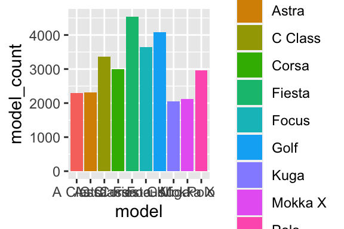

```r
# Selección de los 10 modelos más frecuentes de coches matriculados a partir del 2015 hasta la actualidad.
top_10_used_cars <- used_cars %>% filter(year >= 2015) %>% group_by(manufacturer, model) %>% summarize(model_count=n()) %>% arrange(-model_count) %>% .[0:10,]

top_10_used_cars[,2:3] %>% ggplot(.) + geom_col(aes(model, model_count, fill=model))
```

**Figura 2. Modelos de coches con mayor oferta en el mercado de segunda mano en Julio 2020**

Una vez obtenida dicha información seleccionamos los modelos en nuestro dataset original aplicando los requisitos de antigüedad y precio y mostramos el resultado mediante una serie de gráficos.

```r
# Filtrado de los coches que cumplan los requisitos
#top_10_cars <- used_cars %>% filter((manufacturer %in% top_10_used_cars$manufacturer) & (model %in% top_10_used_cars$model) & (year >= 2015) & (price <= 6000))

top_10_cars <- used_cars %>% filter((manufacturer %in% top_10_used_cars$manufacturer) & (model %in% top_10_used_cars$model) & (year >= 2015) & (price <=20000) & (fuelType == 'Petrol'|fuelType=='Diesel') & (mileage <= 50000))
```

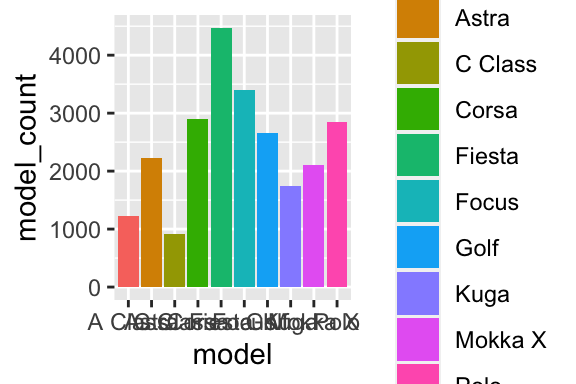

```r
par(mfrow=c(3,3))

# 1. Gráfico que muestra el número de coches por modelo
car_model <- top_10_cars %>% group_by(manufacturer, model) %>% summarize(model_count=n()) %>% arrange(-model_count)
car_model[,2:3] %>% ggplot(.) + geom_col(aes(model, model_count, fill=model))
```

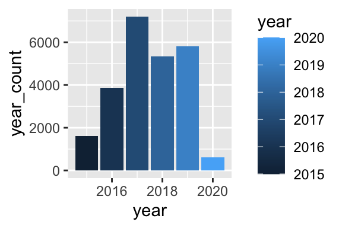

```r
# 2. Gráfico que muestra el número de coches por ano
car_year <- top_10_cars %>% group_by(manufacturer, year) %>% summarize(year_count=n()) %>% arrange(-year_count)

car_year[,2:3] %>% ggplot(.) + geom_col(aes(year, year_count, fill=year))
```

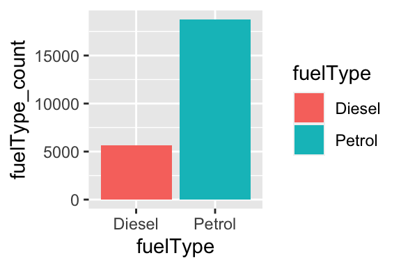

```r
# 3. Gráfico que muestra el número de coches por fuelType
car_fuel <- top_10_cars %>% group_by(manufacturer, fuelType) %>% summarize(fuelType_count=n()) %>% arrange(-fuelType_count)

car_fuel[,2:3] %>% ggplot(.) + geom_col(aes(fuelType, fuelType_count, fill=fuelType))
```

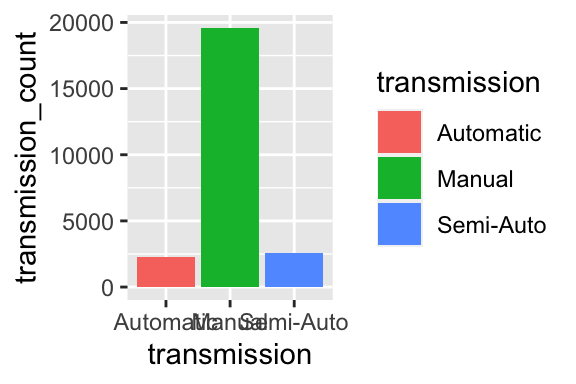

```r
# 4. Gráfico que muestra el número de coches por tipo de transmisión
car_tras <- top_10_cars %>% group_by(manufacturer, transmission) %>% summarize(transmission_count=n()) %>% arrange(-transmission_count)

car_tras[,2:3] %>% ggplot(.) + geom_col(aes(transmission, transmission_count, fill=transmission))
```

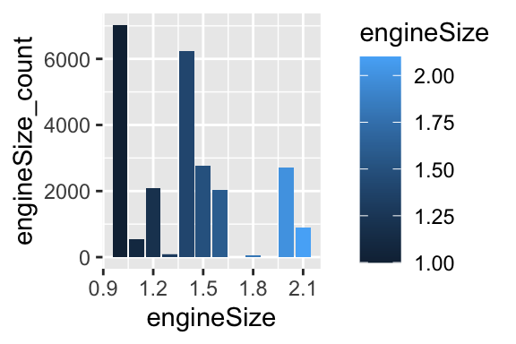

```r
# 5. Gráfico que muestra el número de coches por tipo de engineSize
car_motor <- top_10_cars %>% group_by(manufacturer, engineSize) %>% summarize(engineSize_count=n()) %>% arrange(-engineSize_count)

car_motor[,2:3] %>% ggplot(.) + geom_col(aes(engineSize, engineSize_count, fill=engineSize))
```

**Figura 3. Resumen de las características de los coches con mayor oferta en el mercado**

```r
# Tabla estadística descriptiva de las variables cuantitativas
sk3 <- skim(top_10_cars)
sk3 %>% yank('numeric') %>% select(c(skim_variable, mean, sd, p25, p50, p75)) %>% rename(Variable=skim_variable, Media=mean, "Desviación Típica"=sd, "Q1"=p25, "Q2/Mediana"=p50, "Q3"=p75)  %>% knitr::kable(digits=3, scientific = FALSE)
```

| Variable | Media | Desviación Típica | Q1 | Q2/Mediana | Q3 |
| --- | --- | --- | --- | --- | --- |
| year | 2017.479 | 1.261 | 2017.00 | 2017.0 | 2019.0 |
| price | 12847.554 | 3475.807 | 10000.00 | 12450.0 | 15500.0 |
| mileage | 18280.471 | 11705.361 | 9334.25 | 16257.0 | 26078.0 |
| tax | 121.491 | 50.178 | 125.00 | 145.0 | 145.0 |
| mpg | 55.738 | 9.159 | 48.70 | 55.4 | 61.4 |
| engineSize | 1.382 | 0.337 | 1.00 | 1.4 | 1.5 |

**Tabla 7. Estadística descriptiva de las variable cuantitativas de los coches con mayor oferta**

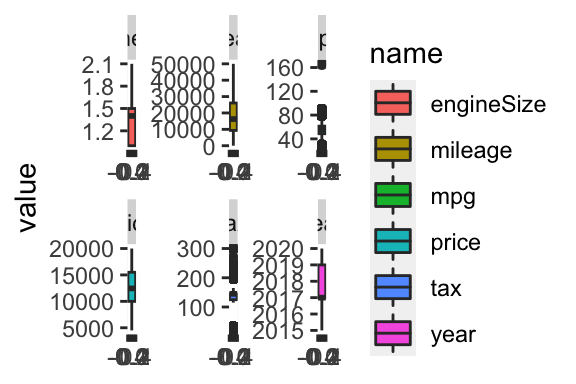

```r
# Boxplot para cada una de las variables númericas (vars)
vars <- c("year", "price", "mileage", "tax", "mpg", "engineSize")

top_10_cars %>% select(vars) %>% pivot_longer(cols=vars, values_drop_na = TRUE) %>% ggplot(.) + facet_wrap(~name, scales = "free") + geom_boxplot(aes(y=value, fill=name))
```

**Figura 4. Diagrama de barras de las características de los coches con mayor oferta**

## 4.2 Comprobación de la normalidad y homogeneidad de la varianza.

Antes de aplicar ningún análisis estadístico comprobamos la normalidad y homogeneidad de los datos. Para ello elegimos dos estrategias, una basada en la representación gráfica de las variables numéricas y la otra en el test de Lilliefors..

- 1. Gráficos Q-Q e Histograma Representamos los datos mediante un histograma y los gráficos de cuantiles teóricos (Gráficos Q-Q) y observamos que, salvo la variable “mileage” (kilometraje), todas las variables se alejan bastante de una distribución normal.

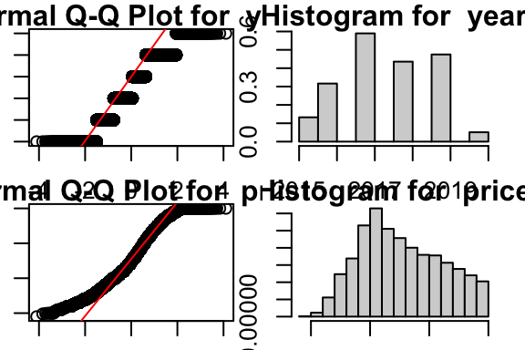

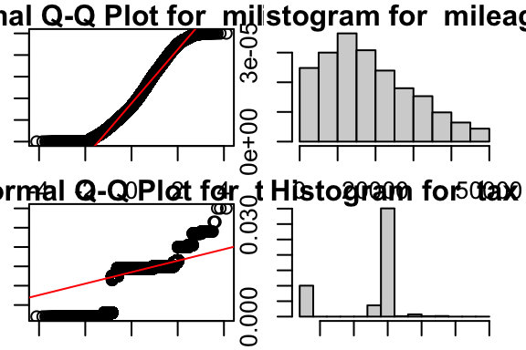

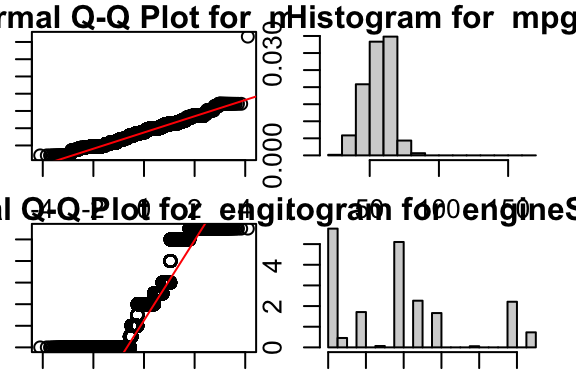

```r
par(mfrow=c(2,2), par(mar=c(1,1,1,1)))
for(i in 1:ncol(top_10_cars)) {
  if (is.numeric(top_10_cars[,i])){
    qqnorm(top_10_cars[,i],main = paste("Normal Q-Q Plot for ",colnames(top_10_cars)[i]))
    qqline(top_10_cars[,i],col="red")
    hist(top_10_cars[,i],
      main=paste("Histogram for ", colnames(top_10_cars)[i]),
      xlab=colnames(top_10_cars)[i], freq = FALSE)
  }
}
```

**Figura 5. Gráficos Q-Q e Histogramas de las variables numéricas de interés**

- 2. Test de Lilliefors para las variables numéricas.

Sin embargo, aplicando el Teorema del Límite Central, asumiremos normalidad a la hora de aplicar los métodos estadísticos detallados a continuación.

## 4.3 Análisis Estadístico

Para ayudar a nuestro cliente a tomar una decisión vamos a aplicar una serie de test estadísticos y su representación gráfica.

- Comparación precio medio por modelo.

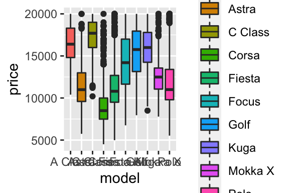

```r
# Gráfico del precio medio y la desviación estándar por modelo de coche
ggplot(top_10_cars, aes(x=model, y=price, fill = model)) + geom_boxplot()
```

Del gráfico anterior observamos una gran diferencia del precio medio en función del modelo que nos permite agruparlos en tres categorias en función del precio: alto (A class, C Class), medio (Focus, Golf, Kuga) y bajo (Astra, Corsa, Fiesta, Mokka X y Polo).

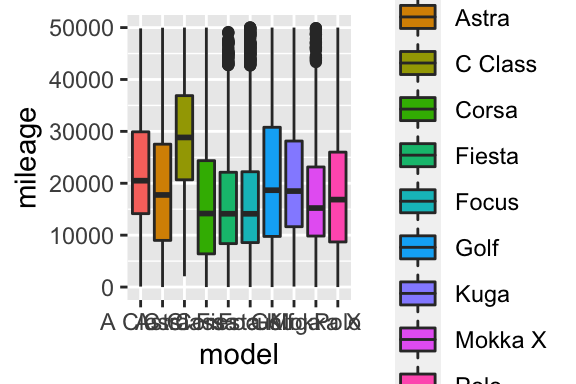

```r
# Gráfico del kilometraje medio y la desviación estándar por modelo de coche
ggplot(top_10_cars, aes(x=model, y=mileage, fill = model)) + geom_boxplot()
```

Dado que el cliente quiere un coche de confianza, del anterior análisis seleccionamos tres modelos (A Class, Focus, Golf) que dadas sus características creemos que le pueden interesar al comprador y estudiamos:

- 1. Análisis del impacto del modelo de coche sobre la mediana de las variables aplicando un análisis de la varianza sobre las variables precio, kilometraje y consumo medio.
- 2. El impacto del kilometraje en el precio del coche aplicando una correlación.
- 3. El impacto del tipo de combustible (petrol vs. diesel) en el precio y kilometraje.

```r
# Selección de tres modelos de coches
three_cars <- c('A Class', 'Focus', 'Golf')
final_cars <- top_10_cars %>% filter((model %in% three_cars))
```

- 1. Análisis del impacto del modelo sobre la media de las variables 1) precio, 2) kilometraje, 3) impuesto de circulación, 4) antigüedad media y 5) consumo medio:

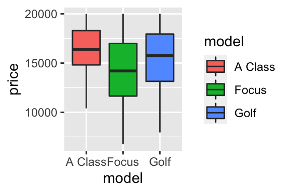

```r
# Gráficos
# 1. Precio medio
ggplot(final_cars, aes(x=model, y=price, fill = model)) + geom_boxplot()
```

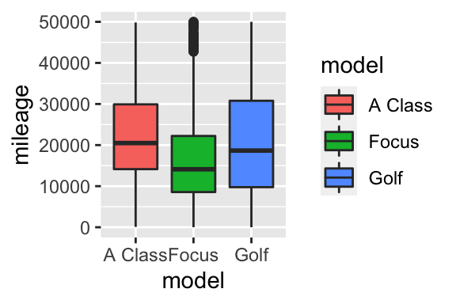

```r
# 2. kilometraje medio
ggplot(final_cars, aes(x=model, y=mileage, fill = model)) + geom_boxplot()
```

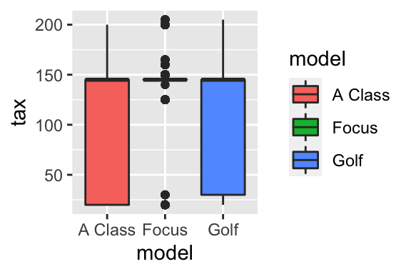

```r
# 3. Impuesto de circulación medio
ggplot(final_cars, aes(x=model, y=tax, fill = model)) + geom_boxplot()
```

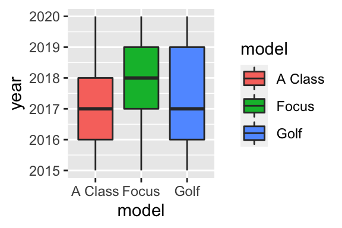

```r
# 4. Antigüedad media
ggplot(final_cars, aes(x=model, y=year, fill = model)) + geom_boxplot()
```

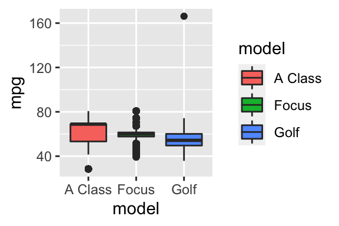

```r
# 5. Consumo medio
ggplot(final_cars, aes(x=model, y=mpg, fill = model)) + geom_boxplot()
```

**Figura 6. Impacto del modelo en la media de las variables cuantitativas**

El análisis de la varianza para cada variable numérica muestra un alto grado de significancia en función del modelo. Nota: sólo se analizan las variables precio (price), kilometraje (mileage) y consumo medio (mpg). Las variables ano (year) y tax están clamente estratificadas por lo que se decide no tener en cuenta para este análisis.

```r
# 1. Cálculo de la varianza de un solo factor (ONE-WAY ANOVA) para precio
res.aov_price <- aov(price ~ model, data = final_cars)
# Resumen del análisis
summary(res.aov_price)
```

```
##               Df    Sum Sq   Mean Sq F value Pr(>F)
## model          2 5.047e+09 2.523e+09   310.4 <2e-16 ***
## Residuals   7274 5.913e+10 8.129e+06
## ---
## Signif. codes:  0 '***' 0.001 '**' 0.01 '*' 0.05 '.' 0.1 ' ' 1
```

```r
# Comparación multiple
TukeyHSD(res.aov_price)
```

```
##   Tukey multiple comparisons of means
##     95% family-wise confidence level
##
## Fit: aov(formula = price ~ model, data = final_cars)
##
## $model
##                     diff       lwr        upr p adj
## Focus-A Class -2127.4531 -2350.236 -1904.6699     0
## Golf-A Class   -803.5211 -1034.294  -572.7481     0
## Golf-Focus     1323.9320  1150.839  1497.0248     0
```

```r
# 2. Cálculo de la varianza de un solo factor (ONE-WAY ANOVA) para mileage
res.aov_mileage <- aov(mileage ~ model, data = final_cars)
# Resumen del análisis
summary(res.aov_mileage)
```

```
##               Df    Sum Sq   Mean Sq F value Pr(>F)
## model          2 4.208e+10 2.104e+10   155.2 <2e-16 ***
## Residuals   7274 9.861e+11 1.356e+08
## ---
## Signif. codes:  0 '***' 0.001 '**' 0.01 '*' 0.05 '.' 0.1 ' ' 1
```

```r
# Comparación multiple
TukeyHSD(res.aov_mileage)
```

```
##   Tukey multiple comparisons of means
##     95% family-wise confidence level
##
## Fit: aov(formula = mileage ~ model, data = final_cars)
##
## $model
##                    diff       lwr       upr   p adj
## Focus-A Class -5980.719 -6890.511 -5070.928 0.0e+00
## Golf-A Class  -1973.776 -2916.196 -1031.356 2.8e-06
## Golf-Focus     4006.943  3300.075  4713.812 0.0e+00
```

```r
# 5. Cálculo de la varianza de un solo factor (ONE-WAY ANOVA) para mpg
res.aov_mpg <- aov(mpg ~ model, data = final_cars)
# Resumen del análisis
summary(res.aov_mpg)
```

```
##               Df Sum Sq Mean Sq F value Pr(>F)
## model          2  65488   32744     399 <2e-16 ***
## Residuals   7274 596878      82
## ---
## Signif. codes:  0 '***' 0.001 '**' 0.01 '*' 0.05 '.' 0.1 ' ' 1
```

```r
# Comparación multiple
TukeyHSD(res.aov_mpg)
```

```
##   Tukey multiple comparisons of means
##     95% family-wise confidence level
##
## Fit: aov(formula = mpg ~ model, data = final_cars)
##
## $model
##                    diff       lwr       upr p adj
## Focus-A Class -4.299427 -5.007261 -3.591594     0
## Golf-A Class  -8.538872 -9.272091 -7.805653     0
## Golf-Focus    -4.239445 -4.789401 -3.689489     0
```

- 2. Impacto del kilometraje en el precio del coche en cada uno de los modelos seleccionados.

En este caso estudiamos dicho impacto en cada uno de los modelos por separado por lo que creamos los correspondientes datasets.

```r
# Crear un dataset por cada modelo
A_Class <- top_10_cars %>% filter(model=='A Class')
Golf <- top_10_cars %>% filter(model=='Golf')
Focus <-  top_10_cars %>% filter(model=='Focus')
```

La correlación entre el kilometraje y el precio es mayor para el coche Class A (-0.65), que indica que a menor kilometraje mayor precio. Para los modelos Golf (-0.50) y Focus (-0.57) esta correlación no es tan clara.

```r
# Correlación entre el kilometraje y el precio
# 1. A_Class
A_Class.cor <- cor(x=A_Class$mileage, y=A_Class$price, method='pearson')
# 2. Golf
Golf.cor <- cor(x=Golf$mileage, y=Golf$price, method='pearson')
# 3. Focus
Focus.cor <- cor(x=Focus$mileage, y=Focus$price, method='pearson')

A_Class.cor
```

```
## [1] -0.6530462
```

```r
Golf.cor
```

```
## [1] -0.5003888
```

```r
Focus.cor
```

```
## [1] -0.5745208
```

[figure not shown]

```r
# Gráficos de dispersión
# 1. A_Class
with(A_Class, plot(x=price, y=mileage, pch=20, col='blue',
                 xlab='Precio', las=1,
                 ylab='Millas'))
```

[figure not shown]

```r
# 2. Golf
with(Golf, plot(x=price, y=mileage, pch=20, col='blue',
                 xlab='Precio', las=1,
                 ylab='Millas'))
```

[figure not shown]

```r
# 3. Focus
with(Focus, plot(x=price, y=mileage, pch=20, col='blue',
                 xlab='Precio', las=1,
                 ylab='Millas'))
```

**Figura 8. Diagramas de dispersión entre el precio y el kilometraje para los tres modelos de coche seleccionados**

*3. El impacto del tipo de combustible (petrol vs. diesel) en el precio y kilometraje

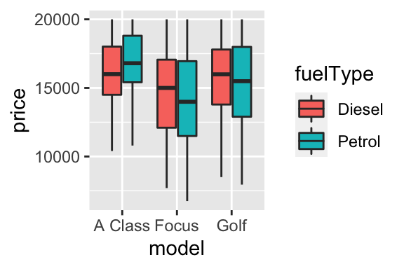

```r
# Gráficos
# 1. Precio vs tipo combustible
ggplot(final_cars, aes(x=model, y=price, fill = fuelType)) + geom_boxplot()
```

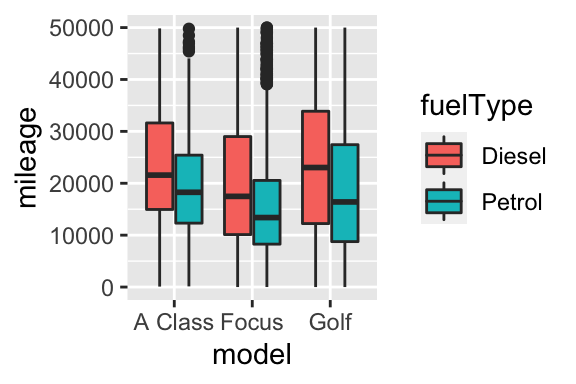

```r
#2. kilometraje vs combustible
ggplot(final_cars, aes(x=model, y=mileage, fill = fuelType)) + geom_boxplot()
```

**Figura 9. Precio y kilometraje en función del tipo de combustible por modelo de coche**

Este análisis no aporta mucha información, sin embargo los gráficos nos permiten sacar las siguientes conclusiones:

1. Para el Focus y Golf el precio de los coches gasolina son más baratos mientras que el clase A es lo contrario.
2. El general los coches diesel tiene más kilometraje que los gasolina.

```r
# Two-way ANOVA precio en función del modelo y tipo de combustible
res.aov <- aov(price ~ model * fuelType, data = final_cars)
summary(res.aov)
```

```
##                  Df    Sum Sq   Mean Sq F value   Pr(>F)
## model             2 5.047e+09 2.523e+09  313.06  < 2e-16 ***
## fuelType          1 1.539e+08 1.539e+08   19.09 1.27e-05 ***
## model:fuelType    2 3.664e+08 1.832e+08   22.73 1.45e-10 ***
## Residuals      7271 5.861e+10 8.060e+06
## ---
## Signif. codes:  0 '***' 0.001 '**' 0.01 '*' 0.05 '.' 0.1 ' ' 1
```

```r
TukeyHSD(res.aov, which = "fuelType")
```

```
##   Tukey multiple comparisons of means
##     95% family-wise confidence level
##
## Fit: aov(formula = price ~ model * fuelType, data = final_cars)
##
## $fuelType
##                    diff      lwr      upr    p adj
## Petrol-Diesel -280.2895 -414.248 -146.331 4.15e-05
```

```r
# Two-way ANOVA precio en función del modelo y tipo de transmisión
res.aov2 <- aov(price ~ model * transmission, data = final_cars)
summary(res.aov2)
```

```
##                      Df    Sum Sq   Mean Sq F value Pr(>F)
## model                 2 5.047e+09 2.523e+09  331.29 <2e-16 ***
## transmission          2 1.993e+09 9.964e+08  130.82 <2e-16 ***
## model:transmission    4 1.775e+09 4.438e+08   58.26 <2e-16 ***
## Residuals          7268 5.536e+10 7.617e+06
## ---
## Signif. codes:  0 '***' 0.001 '**' 0.01 '*' 0.05 '.' 0.1 ' ' 1
```

```r
TukeyHSD(res.aov2, which = "transmission")
```

```
##   Tukey multiple comparisons of means
##     95% family-wise confidence level
##
## Fit: aov(formula = price ~ model * transmission, data = final_cars)
##
## $transmission
##                           diff        lwr        upr p adj
## Manual-Automatic    -1386.0603 -1617.2532 -1154.8673 0e+00
## Semi-Auto-Automatic  -638.0686  -927.4135  -348.7236 7e-07
## Semi-Auto-Manual      747.9917   533.0984   962.8850 0e+00
```

# 5 Análisis 2. Caso práctico compra-venta

Somos una empresa que se dedica a hacer negocio comprando coches baratos, arreglándolos y volviéndolos a vender más caros. Queremos saber qué coches del conjunto de datos se venden al menos un 20% debajo de su precio de mercado (“chollos”) para poder comprarlos y revenderlos.

Para ello vamos a modelar el “mercado de compraventa” mediante un modelo de regresión lineal. Para ello utilizaremos la función “lm” la cual internamente transformará todas las clases de nuestras variables cualitativas en variables dicotómicas para poder obtener el valor estimado como la combinación lineal de todas las variables.

```r
used_cars[] <- lapply(used_cars, function(x) if(is.factor(x)) factor(x) else x)
lm_model <- lm(price~., used_cars)
#lm_model$coefficients Comentado por exceso de páginas
```

Veamos también la correlación de las variables numéricas por si tuvieramos que eliminar alguna del modelo por ser redundante:

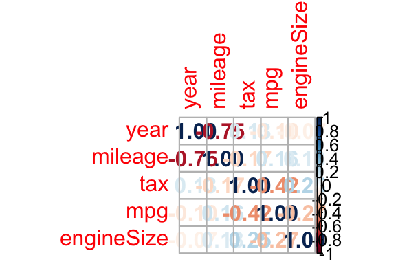

```r
matriz_correl <- cor(used_cars %>% select(c("year","mileage","tax","mpg","engineSize")))
corrplot::corrplot(matriz_correl, method="number")
```

Con el presente modelo podemos responder a la pregunta anterior ¿Cuáles son los chollos del conjunto, coches el 20% por debajo del precio de mercado?

Tenemos que el ~14% está al menos un 20% por debajo del mercado.

```r
mean((lm_model$fitted.values-(used_cars$price*1.2)) > 0)
```

```
## [1] 0.1412599
```

```r
sqrt(mean(lm_model$residuals^2))
```

```
## [1] 3704.997
```

```r
used_cars[(lm_model$fitted.values-(used_cars$price*1.2)) > 0,] %>% sample_n(., 10) %>% knitr::kable()
```

| manufacturer | model | year | price | transmission | mileage | fuelType | tax | mpg | engineSize |
| --- | --- | --- | --- | --- | --- | --- | --- | --- | --- |
| ford | Focus | 2014 | 8000 | Semi-Auto | 30558 | Petrol | 165 | 44.8 | 1.6 |
| vw | Golf | 2016 | 12495 | Manual | 16000 | Petrol | 30 | 53.3 | 1.4 |
| bmw | 4 Series | 2014 | 18250 | Automatic | 18000 | Diesel | 160 | 50.4 | 3.0 |
| merc | A Class | 2017 | 16499 | Automatic | 17490 | Diesel | 145 | 68.9 | 2.1 |
| merc | V Class | 2018 | 18998 | Manual | 24043 | Diesel | 150 | 46.3 | 2.1 |
| merc | C Class | 2015 | 13361 | Semi-Auto | 35034 | Petrol | 125 | 53.3 | 2.0 |
| merc | SL CLASS | 2016 | 19995 | Automatic | 13626 | Diesel | 30 | 70.6 | 2.1 |
| vw | Touareg | 2017 | 25995 | Semi-Auto | 35337 | Diesel | 150 | 42.8 | 3.0 |
| ford | EcoSport | 2016 | 10995 | Automatic | 7600 | Petrol | 160 | 44.8 | 1.5 |
| audi | RS4 | 2013 | 23888 | Automatic | 68000 | Petrol | 555 | 26.4 | 4.2 |

**Tabla 8. 10 modelos de coche con un precio 20% por debajo del mercado

# 6 Conclusiones

Con cada uno de los análisis descritos en este proyecto queremos ayudar al comprador medio y a un vendedor en la toma de decisión a la hora de comprar un coche, tanto para su uso como para su posterior reventa.

En el caso del comprador le hemos propuesto tres modelos que cumplen con los requisitos del cliente. Una vez leido el informe le correspondrá al comprador hacer la elección. Sin embargo, todos los análisis muestran al Focus con una mejor relación-precio en comparación con el Clase A y el Golf.

El análisis del caso “Compra-venta” arroja que el 14% de los coches ofertados están por debajo del 20% del precio de mercado. Pero podemos reconocer que el modelo es mejorable, siendo más restringentes a la hora de seleccionar datos (eliminar outliers, valores altos) y probando con otros modelos como árboles de decisión.

# 7 Exportación del código en R y de los datos producidos.

El código ha sido producido con Rstudio y se produce tanto el PDF como el fichero html ejecutando fichero Rmd con el procesador Knit.

# 8 Contribución

En este proyecto han participado Marta Gómez Galán Y Juan Francisco Nieto Mendoza a partes iguales tanto en la investigación previa como en la redacción y creación de código.